# shinySBM package

## Introduction

This vignette illustrates the use of the {shinySbm} package which is a shiny based graphical user interface (GUI) of the {sbm} package. These packages are made to apply **Stochastic Block Models** on network dataset. This dataset can be in two format: edges list and connection matrix. First we will see how to use the shiny application in the package. And in the second part we will see how to use the external functions as `plotSbm()` and `visSbm()`.

### The shiny application: `shinySbmApp()`

**shinySbmApp()** function contain a {shiny} application which help to use and help to learn the basics of [{sbm}](https://cran.r-project.org/package=sbm) package. Users can import their data inside it and apply **Stochastic Block Models**. They can transform network data from **edges list** to **connection matrix**. Once the SBM ran, users can explore the different number of groups selected by {sbm}. They can get models outputs as: table of parameters, plots, interactive network visuals, automatic reports (pdf or html) (French or English), R script to repeat the analysis outside of the app and tables of block attributions.

The following code show how to run `shinySbmApp()` from your R console.

```r
library(shinySbm)
shinySbmApp()
```

When this is done your browser should load this page. From this page you can import your dataset by clicking on the **Browse** button in embedded in red.

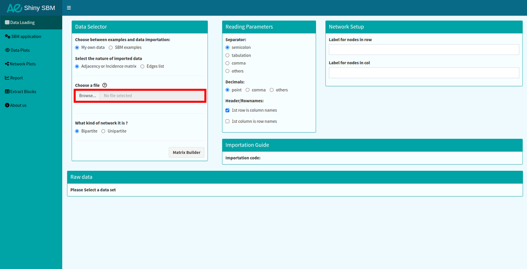

When you load it, the install helper (**1**) can show advice to adjust the importation. For example here, we imported this set as an **Adjacency or Incidence matrix** but as we can see in (**2**), we imported an Edges list. So, we need to change the **nature** of imported data.

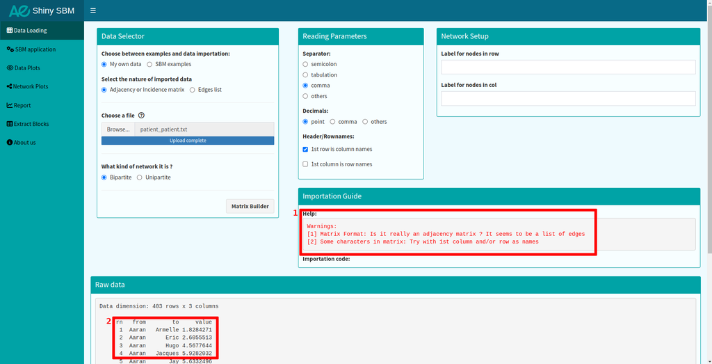

When there is no **warnings** any more, we can then press the button **Matrix Builder**, which will extract essential information from your dataset. If your used an **edges list**, an **adjacency matrix** will be built.

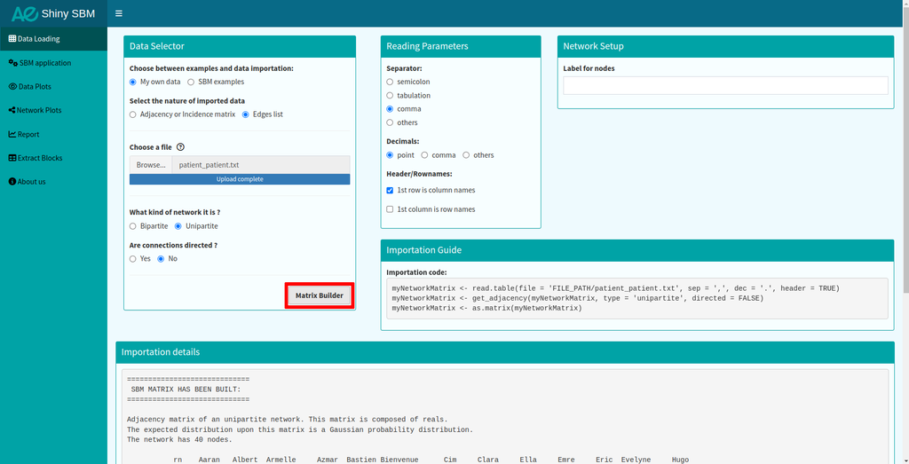

Once the matrix is correctly imported. You should go to the **SBM application** (**1**) page and then click on the **Run SBM** button (**2**). When the calculation are done you will see a small summary from the current model. The small module **Block settings** allows you by clicking on the graph (or numeric input) to select another block number and change the current model. You can also tune your SBM model from this page with the **More Settings** button.

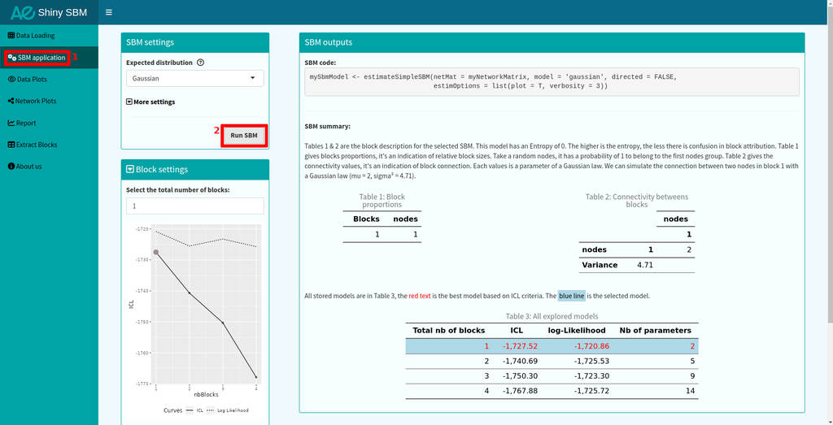

Then it’s time to explore the visuals and outputs in the other pages.

### External functions

The following codes are built by the `shinySbmApp` application, page **Report** with the **R code** option. The next chunk is only made of {sbm} package functions.

```r
# Loading Dataset
myNetworkMatrix <- fungusTreeNetwork$fungus_tree

# Fiting SBM
mySbmModel <- estimateBipartiteSBM(netMat = myNetworkMatrix, model = 'bernoulli',
                                   estimOptions = list(plot = F, verbosity = 0))
```

See this vignette to learn more of {sbm}

```r
vignette("SBM_fungus_tree_network")
```

The function `plotSbm` is a convenient function that can take as arguments: matrices or objects produced by `estimateBipartiteSBM()` and `estimateSimpleSBM()` of {sbm}. It then plot them in a nice matrix of tiles, that can be ordered by blocks or not, transposed etc…

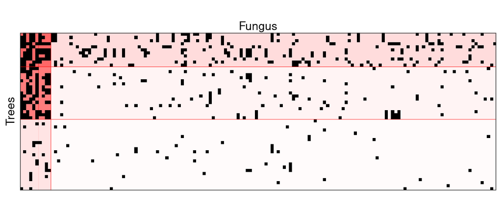

```r
plotSbm(
  mySbmModel,
  ordered = TRUE,
  transpose = TRUE,
  labels = c(row = 'Fungus', col = 'Trees'),
  plotOptions = list(
    showLegend = FALSE,
    showPredictions = TRUE
  ))
```

The function `visSbm` is a convenient function that can take as arguments objects produced by `estimateBipartiteSBM()` and `estimateSimpleSBM()` of {sbm} (it doesn’t take matrices). It make a {visNetwork} type object that represent the network condensed by blocks.

```r
visSbm(
  x = mySbmModel,
  labels = c(row = 'Fungus', col = 'Trees'),
  directed = TRUE,
  settings = list(
    edge_threshold = 'default',
    arrows = TRUE,
    arrow_start = 'row'
  ))
```

[interactive chart not shown]

Thanks for your reading, if any question remain, contact us: shiny.sbm.dev@gmail.com

## References

###### Package SBM

Chiquet J, Donnet S, Barbillon P (2023). *sbm: Stochastic Blockmodels*. R package version 0.4.5, https://CRAN.R-project.org/package=sbm.

###### The demo dataset

Vacher, Corinne, Dominique Piou, and Marie-Laure Desprez-Loustau. “Architecture of an antagonistic tree/fungus network: the asymmetric influence of past evolutionary history.” PloS one 3.3 (2008): e1740.